# Part ivB: Interpretation (Difficult customers)

INFSCI 2595 Final

Ben Stein

4/27/2022

# About this document

In this document, I identify which customers are most difficult to predict in both regression and classification based on all resampling performed during model training.

# Setup

## Libraries & tools

```r
library(tidyverse)
library(caret)
source("./tools.R")
```

## Data

```r
df <- load_project_data(outcome_to_numeric = FALSE)
```

## “Best” models

```r
best_reg_model <- load_model("adv_reg_model10_svm_rbf.rds")
best_cls_model <- load_model("adv_class_model4_continuous_linear.rds")
```

# Tough customers: regression

As I noted in ivA, my top-performing regression model was an SVM with radial basis function. Let’s compute the residuals for each observation (across all resamplings) and group them by customer:

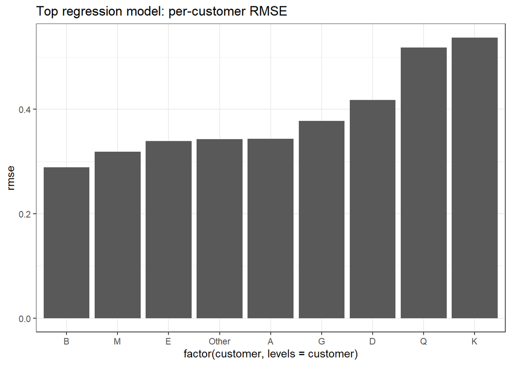

```r
df %>%
  select(customer) %>%
  mutate(row_index = 1:nrow(.)) %>%
  inner_join(best_reg_model$pred, by = c("row_index" = "rowIndex")) %>%
  select(
    customer,
    pred,
    obs
  ) %>%
  group_by(customer) %>%
  summarise(
    rmse = caret::RMSE(pred, obs)
  ) %>%
  arrange(rmse) %>%
  ggplot(mapping = aes(x = factor(customer, levels = customer), y = rmse)) +
  geom_col() +
  ggtitle("Top regression model: per-customer RMSE") +
  theme_bw()
```

Based on the RMSE observed across resamplings, customers K and Q are the most difficult to predict in regression. Maybe they’re moody people?

# Tough customers: classification

Here, I look at how *accurately* the best classification model predicts events for each customer:

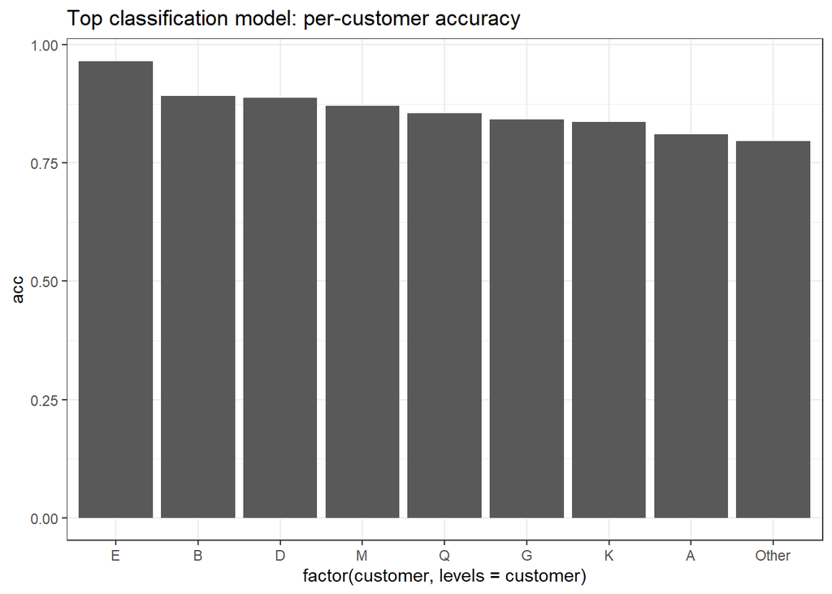

```r
df %>%
  select(customer) %>%
  mutate(row_index = 1:nrow(.)) %>%
  inner_join(best_cls_model$pred, by = c("row_index" = "rowIndex")) %>%
  select(
    customer,
    pred,
    obs,
    event,
    non_event
  ) %>%
  group_by(customer) %>%
  summarise(
    acc = sum(ifelse(obs == pred, 1, 0)) / n()
    # rmse = caret::RMSE(pred, obs)
  ) %>%
  arrange(desc(acc)) %>%
  ggplot(mapping = aes(x = factor(customer, levels = customer), y = acc)) +
  geom_col() +
  ggtitle("Top classification model: per-customer accuracy") +
  theme_bw()
```

Based on this figure, accuracy is closer among customers, but we see that customers `A` and `Other` are the most difficult to classify. `Other` doesn’t surprise me, since I assume it’s an aggregation of a number of customers whose collective behavior may not have clear patterns. However, based on the base rate of the `event` outcome, no model has great accuracy (though we seem to be able to predict customer `E` successfully).